# Risk Factor Analysis

## Outcome Variable

**Outcome Variable:** whz

## Predictor Variables

**Intervention Variable:** predfeed36

**Adjustment Set:**

- arm
- sex
- month
- brthmon
- W_mage
- meducyrs
- feducyrs
- hhwealth_quart
- hfoodsec
- W_mhtcm
- vagbrth
- W_gagebrth
- W_birthwt
- W_birthlen
- W_nrooms
- W_nchldlt5
- W_parity
- impfloor
- impsan
- safeh20
- delta_W_mage
- delta_meducyrs
- delta_feducyrs
- delta_hhwealth_quart
- delta_hfoodsec
- delta_W_mhtcm
- delta_vagbrth
- delta_W_gagebrth
- delta_W_birthwt
- delta_W_birthlen
- delta_W_nrooms
- delta_W_nchldlt5
- delta_W_parity
- delta_impfloor
- delta_impsan
- delta_safeh20

## Stratifying Variables

The analysis was stratified on these variable(s):

- agecat
- studyid
- country

## Data Summary

| agecat | studyid | country | predfeed36 | n_cell | n |
| --- | --- | --- | --- | --- | --- |
| Birth | ki0047075b-MAL-ED | BANGLADESH | 1 | 120 | 230 |
| Birth | ki0047075b-MAL-ED | BANGLADESH | 0 | 110 | 230 |
| Birth | ki0047075b-MAL-ED | BRAZIL | 1 | 28 | 177 |
| Birth | ki0047075b-MAL-ED | BRAZIL | 0 | 149 | 177 |
| Birth | ki0047075b-MAL-ED | INDIA | 1 | 16 | 195 |
| Birth | ki0047075b-MAL-ED | INDIA | 0 | 179 | 195 |
| Birth | ki0047075b-MAL-ED | NEPAL | 1 | 25 | 167 |
| Birth | ki0047075b-MAL-ED | NEPAL | 0 | 142 | 167 |
| Birth | ki0047075b-MAL-ED | PERU | 1 | 116 | 266 |
| Birth | ki0047075b-MAL-ED | PERU | 0 | 150 | 266 |
| Birth | ki0047075b-MAL-ED | SOUTH AFRICA | 1 | 3 | 234 |
| Birth | ki0047075b-MAL-ED | SOUTH AFRICA | 0 | 231 | 234 |
| Birth | ki0047075b-MAL-ED | TANZANIA, UNITED REPUBLIC OF | 1 | 1 | 116 |
| Birth | ki0047075b-MAL-ED | TANZANIA, UNITED REPUBLIC OF | 0 | 115 | 116 |
| Birth | ki1000109-EE | PAKISTAN | 1 | 0 | 1 |
| Birth | ki1000109-EE | PAKISTAN | 0 | 1 | 1 |
| Birth | kiGH5241-JiVitA-3 | BANGLADESH | 1 | 9192 | 11319 |
| Birth | kiGH5241-JiVitA-3 | BANGLADESH | 0 | 2127 | 11319 |
| Birth | kiGH5241-JiVitA-4 | BANGLADESH | 1 | 493 | 602 |
| Birth | kiGH5241-JiVitA-4 | BANGLADESH | 0 | 109 | 602 |
| 6 months | ki0047075b-MAL-ED | BANGLADESH | 1 | 129 | 240 |
| 6 months | ki0047075b-MAL-ED | BANGLADESH | 0 | 111 | 240 |
| 6 months | ki0047075b-MAL-ED | BRAZIL | 1 | 37 | 209 |
| 6 months | ki0047075b-MAL-ED | BRAZIL | 0 | 172 | 209 |
| 6 months | ki0047075b-MAL-ED | INDIA | 1 | 19 | 236 |
| 6 months | ki0047075b-MAL-ED | INDIA | 0 | 217 | 236 |
| 6 months | ki0047075b-MAL-ED | NEPAL | 1 | 32 | 236 |
| 6 months | ki0047075b-MAL-ED | NEPAL | 0 | 204 | 236 |
| 6 months | ki0047075b-MAL-ED | PERU | 1 | 126 | 271 |
| 6 months | ki0047075b-MAL-ED | PERU | 0 | 145 | 271 |
| 6 months | ki0047075b-MAL-ED | SOUTH AFRICA | 1 | 3 | 254 |
| 6 months | ki0047075b-MAL-ED | SOUTH AFRICA | 0 | 251 | 254 |
| 6 months | ki0047075b-MAL-ED | TANZANIA, UNITED REPUBLIC OF | 1 | 2 | 247 |
| 6 months | ki0047075b-MAL-ED | TANZANIA, UNITED REPUBLIC OF | 0 | 245 | 247 |
| 6 months | ki1000109-EE | PAKISTAN | 1 | 224 | 371 |
| 6 months | ki1000109-EE | PAKISTAN | 0 | 147 | 371 |
| 6 months | ki1000304b-SAS-FoodSuppl | INDIA | 1 | 0 | 168 |
| 6 months | ki1000304b-SAS-FoodSuppl | INDIA | 0 | 168 | 168 |
| 6 months | ki1113344-GMS-Nepal | NEPAL | 1 | 423 | 526 |
| 6 months | ki1113344-GMS-Nepal | NEPAL | 0 | 103 | 526 |
| 6 months | ki1148112-LCNI-5 | MALAWI | 1 | 47 | 272 |
| 6 months | ki1148112-LCNI-5 | MALAWI | 0 | 225 | 272 |
| 6 months | kiGH5241-JiVitA-3 | BANGLADESH | 1 | 10674 | 13353 |
| 6 months | kiGH5241-JiVitA-3 | BANGLADESH | 0 | 2679 | 13353 |
| 6 months | kiGH5241-JiVitA-4 | BANGLADESH | 1 | 3255 | 4172 |
| 6 months | kiGH5241-JiVitA-4 | BANGLADESH | 0 | 917 | 4172 |
| 24 months | ki0047075b-MAL-ED | BANGLADESH | 1 | 117 | 211 |
| 24 months | ki0047075b-MAL-ED | BANGLADESH | 0 | 94 | 211 |
| 24 months | ki0047075b-MAL-ED | BRAZIL | 1 | 30 | 169 |
| 24 months | ki0047075b-MAL-ED | BRAZIL | 0 | 139 | 169 |
| 24 months | ki0047075b-MAL-ED | INDIA | 1 | 18 | 227 |
| 24 months | ki0047075b-MAL-ED | INDIA | 0 | 209 | 227 |
| 24 months | ki0047075b-MAL-ED | NEPAL | 1 | 30 | 228 |
| 24 months | ki0047075b-MAL-ED | NEPAL | 0 | 198 | 228 |
| 24 months | ki0047075b-MAL-ED | PERU | 1 | 94 | 200 |
| 24 months | ki0047075b-MAL-ED | PERU | 0 | 106 | 200 |
| 24 months | ki0047075b-MAL-ED | SOUTH AFRICA | 1 | 3 | 238 |
| 24 months | ki0047075b-MAL-ED | SOUTH AFRICA | 0 | 235 | 238 |
| 24 months | ki0047075b-MAL-ED | TANZANIA, UNITED REPUBLIC OF | 1 | 2 | 214 |
| 24 months | ki0047075b-MAL-ED | TANZANIA, UNITED REPUBLIC OF | 0 | 212 | 214 |
| 24 months | ki1113344-GMS-Nepal | NEPAL | 1 | 368 | 455 |
| 24 months | ki1113344-GMS-Nepal | NEPAL | 0 | 87 | 455 |
| 24 months | ki1148112-LCNI-5 | MALAWI | 1 | 34 | 184 |
| 24 months | ki1148112-LCNI-5 | MALAWI | 0 | 150 | 184 |
| 24 months | kiGH5241-JiVitA-3 | BANGLADESH | 1 | 5276 | 6672 |
| 24 months | kiGH5241-JiVitA-3 | BANGLADESH | 0 | 1396 | 6672 |
| 24 months | kiGH5241-JiVitA-4 | BANGLADESH | 1 | 3140 | 4009 |
| 24 months | kiGH5241-JiVitA-4 | BANGLADESH | 0 | 869 | 4009 |

The following strata were considered:

- agecat: 24 months, studyid: ki0047075b-MAL-ED, country: BANGLADESH
- agecat: 24 months, studyid: ki0047075b-MAL-ED, country: BRAZIL
- agecat: 24 months, studyid: ki0047075b-MAL-ED, country: INDIA
- agecat: 24 months, studyid: ki0047075b-MAL-ED, country: NEPAL
- agecat: 24 months, studyid: ki0047075b-MAL-ED, country: PERU
- agecat: 24 months, studyid: ki0047075b-MAL-ED, country: SOUTH AFRICA
- agecat: 24 months, studyid: ki0047075b-MAL-ED, country: TANZANIA, UNITED REPUBLIC OF
- agecat: 24 months, studyid: ki1113344-GMS-Nepal, country: NEPAL
- agecat: 24 months, studyid: ki1148112-LCNI-5, country: MALAWI
- agecat: 24 months, studyid: kiGH5241-JiVitA-3, country: BANGLADESH
- agecat: 24 months, studyid: kiGH5241-JiVitA-4, country: BANGLADESH
- agecat: 6 months, studyid: ki0047075b-MAL-ED, country: BANGLADESH
- agecat: 6 months, studyid: ki0047075b-MAL-ED, country: BRAZIL
- agecat: 6 months, studyid: ki0047075b-MAL-ED, country: INDIA
- agecat: 6 months, studyid: ki0047075b-MAL-ED, country: NEPAL
- agecat: 6 months, studyid: ki0047075b-MAL-ED, country: PERU
- agecat: 6 months, studyid: ki0047075b-MAL-ED, country: SOUTH AFRICA
- agecat: 6 months, studyid: ki0047075b-MAL-ED, country: TANZANIA, UNITED REPUBLIC OF
- agecat: 6 months, studyid: ki1000109-EE, country: PAKISTAN
- agecat: 6 months, studyid: ki1000304b-SAS-FoodSuppl, country: INDIA
- agecat: 6 months, studyid: ki1113344-GMS-Nepal, country: NEPAL
- agecat: 6 months, studyid: ki1148112-LCNI-5, country: MALAWI
- agecat: 6 months, studyid: kiGH5241-JiVitA-3, country: BANGLADESH
- agecat: 6 months, studyid: kiGH5241-JiVitA-4, country: BANGLADESH
- agecat: Birth, studyid: ki0047075b-MAL-ED, country: BANGLADESH
- agecat: Birth, studyid: ki0047075b-MAL-ED, country: BRAZIL
- agecat: Birth, studyid: ki0047075b-MAL-ED, country: INDIA
- agecat: Birth, studyid: ki0047075b-MAL-ED, country: NEPAL
- agecat: Birth, studyid: ki0047075b-MAL-ED, country: PERU
- agecat: Birth, studyid: ki0047075b-MAL-ED, country: SOUTH AFRICA
- agecat: Birth, studyid: ki0047075b-MAL-ED, country: TANZANIA, UNITED REPUBLIC OF
- agecat: Birth, studyid: ki1000109-EE, country: PAKISTAN
- agecat: Birth, studyid: kiGH5241-JiVitA-3, country: BANGLADESH
- agecat: Birth, studyid: kiGH5241-JiVitA-4, country: BANGLADESH

### Dropped Strata

Some strata were dropped due to rare outcomes:

- agecat: Birth, studyid: ki0047075b-MAL-ED, country: SOUTH AFRICA
- agecat: Birth, studyid: ki0047075b-MAL-ED, country: TANZANIA, UNITED REPUBLIC OF
- agecat: Birth, studyid: ki1000109-EE, country: PAKISTAN
- agecat: 6 months, studyid: ki0047075b-MAL-ED, country: SOUTH AFRICA
- agecat: 6 months, studyid: ki0047075b-MAL-ED, country: TANZANIA, UNITED REPUBLIC OF
- agecat: 6 months, studyid: ki1000304b-SAS-FoodSuppl, country: INDIA
- agecat: 24 months, studyid: ki0047075b-MAL-ED, country: SOUTH AFRICA
- agecat: 24 months, studyid: ki0047075b-MAL-ED, country: TANZANIA, UNITED REPUBLIC OF

## Methods Detail

We’re interested in the causal parameters $E[Y_a]$ for all values of $a \in \mathcal{A}$. These parameters represent the mean outcome if, possibly contrary to fact, we intervened to set all units to have $A=a$. Under the randomization and positivity assumptions, these are identified by the statistical parameters $\psi_a=E_W[E_{Y|A,W}(Y|A=a,W)]$. In addition, we’re interested in the mean of $Y$, $E[Y]$ under no intervention (the observed mean). We will estimate these parameters by using SuperLearner to fit the relevant likelihood factors – $E_{Y|A,W}(Y|A=a,W)$ and $p(A=a|W)$, and then updating our likelihood fit using a joint TMLE.

For unadjusted analyses ($W=\{\}$), initial likelihoods were estimated using Lrnr_glm to estimate the simple $E(Y|A)$ and Lrnr_mean to estimate $p(A)$. For adjusted analyses, a small library containing Lrnr_glmnet, Lrnr_xgboost, and Lrnr_mean was used.

Having estimated these parameters, we will then use the delta method to estimate relative risks and attributable risks relative to a prespecified baseline level of $A$.

# Results Detail

## Results Plots

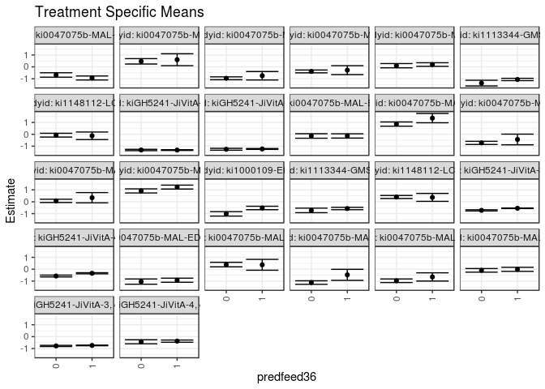

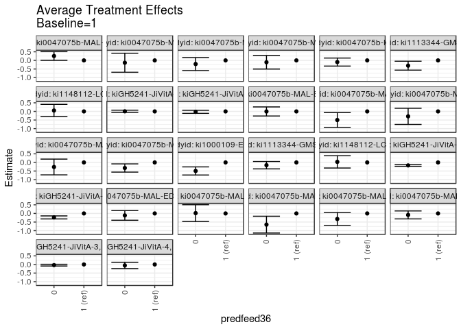

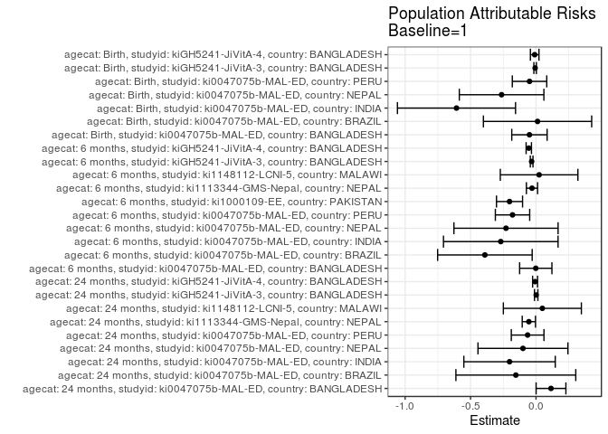

## Results Table

### Parameter: TSM

| agecat | studyid | country | intervention_level | baseline_level | estimate | ci_lower | ci_upper |
| --- | --- | --- | --- | --- | --- | --- | --- |
| Birth | ki0047075b-MAL-ED | BANGLADESH | 1 | NA | -0.9271593 | -1.0993745 | -0.7549440 |
| Birth | ki0047075b-MAL-ED | BANGLADESH | 0 | NA | -1.0419071 | -1.2624456 | -0.8213686 |
| Birth | ki0047075b-MAL-ED | BRAZIL | 1 | NA | 0.3719806 | -0.0859771 | 0.8299383 |
| Birth | ki0047075b-MAL-ED | BRAZIL | 0 | NA | 0.3908435 | 0.1999372 | 0.5817497 |
| Birth | ki0047075b-MAL-ED | INDIA | 1 | NA | -0.4740360 | -0.9385833 | -0.0094887 |
| Birth | ki0047075b-MAL-ED | INDIA | 0 | NA | -1.1236379 | -1.2721272 | -0.9751486 |
| Birth | ki0047075b-MAL-ED | NEPAL | 1 | NA | -0.6498019 | -0.9964165 | -0.3031874 |
| Birth | ki0047075b-MAL-ED | NEPAL | 0 | NA | -0.9723347 | -1.1228728 | -0.8217967 |
| Birth | ki0047075b-MAL-ED | PERU | 1 | NA | -0.0107791 | -0.1805537 | 0.1589954 |
| Birth | ki0047075b-MAL-ED | PERU | 0 | NA | -0.0968926 | -0.2499802 | 0.0561950 |
| Birth | kiGH5241-JiVitA-3 | BANGLADESH | 1 | NA | -0.7378424 | -0.7624984 | -0.7131864 |
| Birth | kiGH5241-JiVitA-3 | BANGLADESH | 0 | NA | -0.7774938 | -0.8262423 | -0.7287452 |
| Birth | kiGH5241-JiVitA-4 | BANGLADESH | 1 | NA | -0.3760696 | -0.4696290 | -0.2825102 |
| Birth | kiGH5241-JiVitA-4 | BANGLADESH | 0 | NA | -0.4324870 | -0.6016793 | -0.2632948 |
| 6 months | ki0047075b-MAL-ED | BANGLADESH | 1 | NA | -0.1382378 | -0.3184498 | 0.0419741 |
| 6 months | ki0047075b-MAL-ED | BANGLADESH | 0 | NA | -0.1414213 | -0.3319836 | 0.0491410 |
| 6 months | ki0047075b-MAL-ED | BRAZIL | 1 | NA | 1.3621954 | 0.9691470 | 1.7552438 |
| 6 months | ki0047075b-MAL-ED | BRAZIL | 0 | NA | 0.8622841 | 0.6833948 | 1.0411733 |
| 6 months | ki0047075b-MAL-ED | INDIA | 1 | NA | -0.4342001 | -0.8837613 | 0.0153612 |
| 6 months | ki0047075b-MAL-ED | INDIA | 0 | NA | -0.7212070 | -0.8528675 | -0.5895466 |
| 6 months | ki0047075b-MAL-ED | NEPAL | 1 | NA | 0.3403415 | -0.0922732 | 0.7729562 |
| 6 months | ki0047075b-MAL-ED | NEPAL | 0 | NA | 0.0757484 | -0.0623981 | 0.2138949 |
| 6 months | ki0047075b-MAL-ED | PERU | 1 | NA | 1.2356359 | 1.0703821 | 1.4008898 |
| 6 months | ki0047075b-MAL-ED | PERU | 0 | NA | 0.9126735 | 0.7393654 | 1.0859817 |
| 6 months | ki1000109-EE | PAKISTAN | 1 | NA | -0.5232735 | -0.6669728 | -0.3795742 |
| 6 months | ki1000109-EE | PAKISTAN | 0 | NA | -1.0190972 | -1.2056121 | -0.8325823 |
| 6 months | ki1113344-GMS-Nepal | NEPAL | 1 | NA | -0.5700232 | -0.6703931 | -0.4696533 |
| 6 months | ki1113344-GMS-Nepal | NEPAL | 0 | NA | -0.7299656 | -0.9207473 | -0.5391839 |
| 6 months | ki1148112-LCNI-5 | MALAWI | 1 | NA | 0.3690677 | 0.0354666 | 0.7026689 |
| 6 months | ki1148112-LCNI-5 | MALAWI | 0 | NA | 0.4014661 | 0.2743851 | 0.5285471 |
| 6 months | kiGH5241-JiVitA-3 | BANGLADESH | 1 | NA | -0.5501743 | -0.5739584 | -0.5263903 |
| 6 months | kiGH5241-JiVitA-3 | BANGLADESH | 0 | NA | -0.7233549 | -0.7712184 | -0.6754914 |
| 6 months | kiGH5241-JiVitA-4 | BANGLADESH | 1 | NA | -0.3421942 | -0.3893609 | -0.2950274 |
| 6 months | kiGH5241-JiVitA-4 | BANGLADESH | 0 | NA | -0.5727007 | -0.6490089 | -0.4963925 |
| 24 months | ki0047075b-MAL-ED | BANGLADESH | 1 | NA | -0.9373874 | -1.1064614 | -0.7683134 |
| 24 months | ki0047075b-MAL-ED | BANGLADESH | 0 | NA | -0.6824661 | -0.8679772 | -0.4969549 |
| 24 months | ki0047075b-MAL-ED | BRAZIL | 1 | NA | 0.6007377 | 0.0989888 | 1.1024867 |
| 24 months | ki0047075b-MAL-ED | BRAZIL | 0 | NA | 0.4650961 | 0.2387807 | 0.6914116 |
| 24 months | ki0047075b-MAL-ED | INDIA | 1 | NA | -0.7501766 | -1.1057136 | -0.3946396 |
| 24 months | ki0047075b-MAL-ED | INDIA | 0 | NA | -0.9629511 | -1.0850612 | -0.8408410 |
| 24 months | ki0047075b-MAL-ED | NEPAL | 1 | NA | -0.2767068 | -0.6530393 | 0.0996256 |
| 24 months | ki0047075b-MAL-ED | NEPAL | 0 | NA | -0.3849474 | -0.5028604 | -0.2670344 |
| 24 months | ki0047075b-MAL-ED | PERU | 1 | NA | 0.1941453 | 0.0439396 | 0.3443511 |
| 24 months | ki0047075b-MAL-ED | PERU | 0 | NA | 0.0972664 | -0.0836223 | 0.2781551 |
| 24 months | ki1113344-GMS-Nepal | NEPAL | 1 | NA | -1.0641221 | -1.1617779 | -0.9664663 |
| 24 months | ki1113344-GMS-Nepal | NEPAL | 0 | NA | -1.3695711 | -1.6091468 | -1.1299955 |
| 24 months | ki1148112-LCNI-5 | MALAWI | 1 | NA | -0.1257302 | -0.4442761 | 0.1928156 |
| 24 months | ki1148112-LCNI-5 | MALAWI | 0 | NA | -0.0731349 | -0.2329918 | 0.0867221 |
| 24 months | kiGH5241-JiVitA-3 | BANGLADESH | 1 | NA | -1.3259326 | -1.3568234 | -1.2950418 |
| 24 months | kiGH5241-JiVitA-3 | BANGLADESH | 0 | NA | -1.3193422 | -1.3765007 | -1.2621836 |
| 24 months | kiGH5241-JiVitA-4 | BANGLADESH | 1 | NA | -1.2348429 | -1.2732024 | -1.1964833 |
| 24 months | kiGH5241-JiVitA-4 | BANGLADESH | 0 | NA | -1.2596159 | -1.3400824 | -1.1791493 |

### Parameter: E(Y)

| agecat | studyid | country | intervention_level | baseline_level | estimate | ci_lower | ci_upper |
| --- | --- | --- | --- | --- | --- | --- | --- |
| Birth | ki0047075b-MAL-ED | BANGLADESH | NA | NA | -0.9773043 | -1.1153078 | -0.8393008 |
| Birth | ki0047075b-MAL-ED | BRAZIL | NA | NA | 0.3837288 | 0.2059602 | 0.5614974 |
| Birth | ki0047075b-MAL-ED | INDIA | NA | NA | -1.0816410 | -1.2241126 | -0.9391694 |
| Birth | ki0047075b-MAL-ED | NEPAL | NA | NA | -0.9126946 | -1.0520834 | -0.7733058 |
| Birth | ki0047075b-MAL-ED | PERU | NA | NA | -0.0602256 | -0.1729666 | 0.0525155 |
| Birth | kiGH5241-JiVitA-3 | BANGLADESH | NA | NA | -0.7445605 | -0.7677110 | -0.7214100 |
| Birth | kiGH5241-JiVitA-4 | BANGLADESH | NA | NA | -0.3861794 | -0.4712311 | -0.3011277 |
| 6 months | ki0047075b-MAL-ED | BANGLADESH | NA | NA | -0.1400243 | -0.2696346 | -0.0104140 |
| 6 months | ki0047075b-MAL-ED | BRAZIL | NA | NA | 0.9717225 | 0.8073791 | 1.1360658 |
| 6 months | ki0047075b-MAL-ED | INDIA | NA | NA | -0.7033969 | -0.8285284 | -0.5782654 |
| 6 months | ki0047075b-MAL-ED | NEPAL | NA | NA | 0.1110452 | -0.0202712 | 0.2423616 |
| 6 months | ki0047075b-MAL-ED | PERU | NA | NA | 1.0562362 | 0.9338834 | 1.1785889 |
| 6 months | ki1000109-EE | PAKISTAN | NA | NA | -0.7256065 | -0.8395859 | -0.6116270 |
| 6 months | ki1113344-GMS-Nepal | NEPAL | NA | NA | -0.6007161 | -0.6897580 | -0.5116742 |
| 6 months | ki1148112-LCNI-5 | MALAWI | NA | NA | 0.3927574 | 0.2737700 | 0.5117448 |
| 6 months | kiGH5241-JiVitA-3 | BANGLADESH | NA | NA | -0.5834618 | -0.6054534 | -0.5614701 |
| 6 months | kiGH5241-JiVitA-4 | BANGLADESH | NA | NA | -0.3973178 | -0.4385298 | -0.3561058 |
| 24 months | ki0047075b-MAL-ED | BANGLADESH | NA | NA | -0.8227962 | -0.9454140 | -0.7001785 |
| 24 months | ki0047075b-MAL-ED | BRAZIL | NA | NA | 0.4466272 | 0.2416144 | 0.6516401 |
| 24 months | ki0047075b-MAL-ED | INDIA | NA | NA | -0.9522907 | -1.0676596 | -0.8369219 |
| 24 months | ki0047075b-MAL-ED | NEPAL | NA | NA | -0.3764474 | -0.4898516 | -0.2630431 |
| 24 months | ki0047075b-MAL-ED | PERU | NA | NA | 0.1302000 | 0.0113848 | 0.2490152 |
| 24 months | ki1113344-GMS-Nepal | NEPAL | NA | NA | -1.1186923 | -1.2105469 | -1.0268377 |
| 24 months | ki1148112-LCNI-5 | MALAWI | NA | NA | -0.0771196 | -0.2204715 | 0.0662323 |
| 24 months | kiGH5241-JiVitA-3 | BANGLADESH | NA | NA | -1.3246418 | -1.3519597 | -1.2973238 |
| 24 months | kiGH5241-JiVitA-4 | BANGLADESH | NA | NA | -1.2418558 | -1.2769820 | -1.2067296 |

### Parameter: ATE

| agecat | studyid | country | intervention_level | baseline_level | estimate | ci_lower | ci_upper |
| --- | --- | --- | --- | --- | --- | --- | --- |
| Birth | ki0047075b-MAL-ED | BANGLADESH | 1 | 1 | 0.0000000 | 0.0000000 | 0.0000000 |
| Birth | ki0047075b-MAL-ED | BANGLADESH | 0 | 1 | -0.1147479 | -0.3957274 | 0.1662317 |
| Birth | ki0047075b-MAL-ED | BRAZIL | 1 | 1 | 0.0000000 | 0.0000000 | 0.0000000 |
| Birth | ki0047075b-MAL-ED | BRAZIL | 0 | 1 | 0.0188629 | -0.4691090 | 0.5068348 |
| Birth | ki0047075b-MAL-ED | INDIA | 1 | 1 | 0.0000000 | 0.0000000 | 0.0000000 |
| Birth | ki0047075b-MAL-ED | INDIA | 0 | 1 | -0.6496019 | -1.1377168 | -0.1614871 |
| Birth | ki0047075b-MAL-ED | NEPAL | 1 | 1 | 0.0000000 | 0.0000000 | 0.0000000 |
| Birth | ki0047075b-MAL-ED | NEPAL | 0 | 1 | -0.3225328 | -0.6996457 | 0.0545801 |
| Birth | ki0047075b-MAL-ED | PERU | 1 | 1 | 0.0000000 | 0.0000000 | 0.0000000 |
| Birth | ki0047075b-MAL-ED | PERU | 0 | 1 | -0.0861134 | -0.3175638 | 0.1453369 |
| Birth | kiGH5241-JiVitA-3 | BANGLADESH | 1 | 1 | 0.0000000 | 0.0000000 | 0.0000000 |
| Birth | kiGH5241-JiVitA-3 | BANGLADESH | 0 | 1 | -0.0396514 | -0.0904411 | 0.0111383 |
| Birth | kiGH5241-JiVitA-4 | BANGLADESH | 1 | 1 | 0.0000000 | 0.0000000 | 0.0000000 |
| Birth | kiGH5241-JiVitA-4 | BANGLADESH | 0 | 1 | -0.0564175 | -0.2417009 | 0.1288659 |
| 6 months | ki0047075b-MAL-ED | BANGLADESH | 1 | 1 | 0.0000000 | 0.0000000 | 0.0000000 |
| 6 months | ki0047075b-MAL-ED | BANGLADESH | 0 | 1 | -0.0031835 | -0.2666999 | 0.2603329 |
| 6 months | ki0047075b-MAL-ED | BRAZIL | 1 | 1 | 0.0000000 | 0.0000000 | 0.0000000 |
| 6 months | ki0047075b-MAL-ED | BRAZIL | 0 | 1 | -0.4999113 | -0.9334591 | -0.0663635 |
| 6 months | ki0047075b-MAL-ED | INDIA | 1 | 1 | 0.0000000 | 0.0000000 | 0.0000000 |
| 6 months | ki0047075b-MAL-ED | INDIA | 0 | 1 | -0.2870070 | -0.7561814 | 0.1821674 |
| 6 months | ki0047075b-MAL-ED | NEPAL | 1 | 1 | 0.0000000 | 0.0000000 | 0.0000000 |
| 6 months | ki0047075b-MAL-ED | NEPAL | 0 | 1 | -0.2645931 | -0.7217474 | 0.1925612 |
| 6 months | ki0047075b-MAL-ED | PERU | 1 | 1 | 0.0000000 | 0.0000000 | 0.0000000 |
| 6 months | ki0047075b-MAL-ED | PERU | 0 | 1 | -0.3229624 | -0.5622254 | -0.0836994 |
| 6 months | ki1000109-EE | PAKISTAN | 1 | 1 | 0.0000000 | 0.0000000 | 0.0000000 |
| 6 months | ki1000109-EE | PAKISTAN | 0 | 1 | -0.4958237 | -0.7314456 | -0.2602018 |
| 6 months | ki1113344-GMS-Nepal | NEPAL | 1 | 1 | 0.0000000 | 0.0000000 | 0.0000000 |
| 6 months | ki1113344-GMS-Nepal | NEPAL | 0 | 1 | -0.1599424 | -0.3756696 | 0.0557849 |
| 6 months | ki1148112-LCNI-5 | MALAWI | 1 | 1 | 0.0000000 | 0.0000000 | 0.0000000 |
| 6 months | ki1148112-LCNI-5 | MALAWI | 0 | 1 | 0.0323984 | -0.3249879 | 0.3897846 |
| 6 months | kiGH5241-JiVitA-3 | BANGLADESH | 1 | 1 | 0.0000000 | 0.0000000 | 0.0000000 |
| 6 months | kiGH5241-JiVitA-3 | BANGLADESH | 0 | 1 | -0.1731806 | -0.2240243 | -0.1223368 |
| 6 months | kiGH5241-JiVitA-4 | BANGLADESH | 1 | 1 | 0.0000000 | 0.0000000 | 0.0000000 |
| 6 months | kiGH5241-JiVitA-4 | BANGLADESH | 0 | 1 | -0.2305066 | -0.3181505 | -0.1428626 |
| 24 months | ki0047075b-MAL-ED | BANGLADESH | 1 | 1 | 0.0000000 | 0.0000000 | 0.0000000 |
| 24 months | ki0047075b-MAL-ED | BANGLADESH | 0 | 1 | 0.2549213 | 0.0024356 | 0.5074070 |
| 24 months | ki0047075b-MAL-ED | BRAZIL | 1 | 1 | 0.0000000 | 0.0000000 | 0.0000000 |
| 24 months | ki0047075b-MAL-ED | BRAZIL | 0 | 1 | -0.1356416 | -0.6881080 | 0.4168248 |
| 24 months | ki0047075b-MAL-ED | INDIA | 1 | 1 | 0.0000000 | 0.0000000 | 0.0000000 |
| 24 months | ki0047075b-MAL-ED | INDIA | 0 | 1 | -0.2127745 | -0.5894572 | 0.1639082 |
| 24 months | ki0047075b-MAL-ED | NEPAL | 1 | 1 | 0.0000000 | 0.0000000 | 0.0000000 |
| 24 months | ki0047075b-MAL-ED | NEPAL | 0 | 1 | -0.1082406 | -0.5023959 | 0.2859147 |
| 24 months | ki0047075b-MAL-ED | PERU | 1 | 1 | 0.0000000 | 0.0000000 | 0.0000000 |
| 24 months | ki0047075b-MAL-ED | PERU | 0 | 1 | -0.0968790 | -0.3303149 | 0.1365569 |
| 24 months | ki1113344-GMS-Nepal | NEPAL | 1 | 1 | 0.0000000 | 0.0000000 | 0.0000000 |
| 24 months | ki1113344-GMS-Nepal | NEPAL | 0 | 1 | -0.3054490 | -0.5643322 | -0.0465658 |
| 24 months | ki1148112-LCNI-5 | MALAWI | 1 | 1 | 0.0000000 | 0.0000000 | 0.0000000 |
| 24 months | ki1148112-LCNI-5 | MALAWI | 0 | 1 | 0.0525954 | -0.3045322 | 0.4097229 |
| 24 months | kiGH5241-JiVitA-3 | BANGLADESH | 1 | 1 | 0.0000000 | 0.0000000 | 0.0000000 |
| 24 months | kiGH5241-JiVitA-3 | BANGLADESH | 0 | 1 | 0.0065904 | -0.0575527 | 0.0707336 |
| 24 months | kiGH5241-JiVitA-4 | BANGLADESH | 1 | 1 | 0.0000000 | 0.0000000 | 0.0000000 |
| 24 months | kiGH5241-JiVitA-4 | BANGLADESH | 0 | 1 | -0.0247730 | -0.1117177 | 0.0621716 |

### Parameter: PAR

| agecat | studyid | country | intervention_level | baseline_level | estimate | ci_lower | ci_upper |
| --- | --- | --- | --- | --- | --- | --- | --- |
| Birth | ki0047075b-MAL-ED | BANGLADESH | 1 | NA | -0.0501451 | -0.1851937 | 0.0849035 |
| Birth | ki0047075b-MAL-ED | BRAZIL | 1 | NA | 0.0117482 | -0.4019029 | 0.4253993 |
| Birth | ki0047075b-MAL-ED | INDIA | 1 | NA | -0.6076050 | -1.0588346 | -0.1563754 |
| Birth | ki0047075b-MAL-ED | NEPAL | 1 | NA | -0.2628927 | -0.5860283 | 0.0602429 |
| Birth | ki0047075b-MAL-ED | PERU | 1 | NA | -0.0494464 | -0.1810734 | 0.0821805 |
| Birth | kiGH5241-JiVitA-3 | BANGLADESH | 1 | NA | -0.0067181 | -0.0162309 | 0.0027947 |
| Birth | kiGH5241-JiVitA-4 | BANGLADESH | 1 | NA | -0.0101098 | -0.0428016 | 0.0225819 |
| 6 months | ki0047075b-MAL-ED | BANGLADESH | 1 | NA | -0.0017865 | -0.1251190 | 0.1215461 |
| 6 months | ki0047075b-MAL-ED | BRAZIL | 1 | NA | -0.3904729 | -0.7517040 | -0.0292418 |
| 6 months | ki0047075b-MAL-ED | INDIA | 1 | NA | -0.2691968 | -0.7069541 | 0.1685604 |
| 6 months | ki0047075b-MAL-ED | NEPAL | 1 | NA | -0.2292963 | -0.6273243 | 0.1687317 |
| 6 months | ki0047075b-MAL-ED | PERU | 1 | NA | -0.1793998 | -0.3106046 | -0.0481950 |
| 6 months | ki1000109-EE | PAKISTAN | 1 | NA | -0.2023330 | -0.3019668 | -0.1026991 |
| 6 months | ki1113344-GMS-Nepal | NEPAL | 1 | NA | -0.0306929 | -0.0734161 | 0.0120303 |
| 6 months | ki1148112-LCNI-5 | MALAWI | 1 | NA | 0.0236896 | -0.2726997 | 0.3200789 |
| 6 months | kiGH5241-JiVitA-3 | BANGLADESH | 1 | NA | -0.0332874 | -0.0435066 | -0.0230682 |
| 6 months | kiGH5241-JiVitA-4 | BANGLADESH | 1 | NA | -0.0551237 | -0.0755529 | -0.0346944 |
| 24 months | ki0047075b-MAL-ED | BANGLADESH | 1 | NA | 0.1145912 | 0.0007646 | 0.2284177 |
| 24 months | ki0047075b-MAL-ED | BRAZIL | 1 | NA | -0.1541105 | -0.6120734 | 0.3038524 |
| 24 months | ki0047075b-MAL-ED | INDIA | 1 | NA | -0.2021141 | -0.5513710 | 0.1471428 |
| 24 months | ki0047075b-MAL-ED | NEPAL | 1 | NA | -0.0997405 | -0.4433744 | 0.2438934 |
| 24 months | ki0047075b-MAL-ED | PERU | 1 | NA | -0.0639453 | -0.1887105 | 0.0608198 |
| 24 months | ki1113344-GMS-Nepal | NEPAL | 1 | NA | -0.0545702 | -0.1052968 | -0.0038435 |
| 24 months | ki1148112-LCNI-5 | MALAWI | 1 | NA | 0.0486106 | -0.2494329 | 0.3466542 |
| 24 months | kiGH5241-JiVitA-3 | BANGLADESH | 1 | NA | 0.0012908 | -0.0118665 | 0.0144482 |
| 24 months | kiGH5241-JiVitA-4 | BANGLADESH | 1 | NA | -0.0070130 | -0.0259167 | 0.0118908 |